# Final Project

Final Project for the Summer Course of Python for Social Sciences given by QLAB. Our task was to graph and analyse a database provided by the lecturer. It is published as a html page at: https://estcab00.github.io/final-project-python-CCSS/

### Authors:

- Cabrera Bonilla, Esteban Simón (20190478) (esteban.cabrera@pucp.edu.pe)
- Egusquiza Portillo, Luis Fernando (20193469) (egusquiza.l@pucp.edu.pe)

# 1. Libraries

```python
import pandas as pd
import numpy as np
import matplotlib.pyplot as plt
import seaborn as sns
import warnings

warnings.filterwarnings("ignore")
```

# 2. Read the file

We read the CSV file and inspect.

```python
df = pd.read_csv('data/51f7ab6a-24ed-4a06-9f5d-04873f1673fd_Data-1.csv')
df.head()
```

|  | Country Name | Country Code | Series Name | Series Code | 1960 [YR1960] | 1961 [YR1961] | 1962 [YR1962] | 1963 [YR1963] | 1964 [YR1964] | 1965 [YR1965] | ... | 2013 [YR2013] | 2014 [YR2014] | 2015 [YR2015] | 2016 [YR2016] | 2017 [YR2017] | 2018 [YR2018] | 2019 [YR2019] | 2020 [YR2020] | 2021 [YR2021] | 2022 [YR2022] |
| --- | --- | --- | --- | --- | --- | --- | --- | --- | --- | --- | --- | --- | --- | --- | --- | --- | --- | --- | --- | --- | --- |
| 0 | Afghanistan | AFG | Access to electricity (% of population) | EG.ELC.ACCS.ZS | .. | .. | .. | .. | .. | .. | ... | 68.0408782958984 | 89.5 | 71.5 | 97.7 | 97.7 | 93.4308776855469 | 97.7 | 97.7 | 97.7 | .. |
| 1 | Afghanistan | AFG | Access to electricity, rural (% of rural popul... | EG.ELC.ACCS.RU.ZS | .. | .. | .. | .. | .. | .. | ... | 60.2391977225107 | 86.5005116269173 | 64.5733543829493 | 97.0993598284929 | 97.0919732482142 | 91.6060600230095 | 97.0756269501314 | 97.0667125932952 | 97.0572022178384 | .. |
| 2 | Afghanistan | AFG | CO2 emissions (metric tons per capita) | EN.ATM.CO2E.PC | .. | .. | .. | .. | .. | .. | ... | 0.29808781267706 | 0.283692395910162 | 0.297971774718822 | 0.268358772656602 | 0.281195815732375 | 0.299082634225993 | 0.297563650500103 | 0.223478872007068 | .. | .. |
| 3 | Afghanistan | AFG | GDP growth (annual %) | NY.GDP.MKTP.KD.ZG | .. | .. | .. | .. | .. | .. | ... | 5.60074465808174 | 2.72454336394887 | 1.45131466009762 | 2.26031420130457 | 2.6470032019574 | 1.18922812838036 | 3.91160341942292 | -2.3511006734461 | -20.7388393676343 | .. |
| 4 | Afghanistan | AFG | Hospital beds (per 1,000 people) | SH.MED.BEDS.ZS | 0.170626997947693 | .. | .. | .. | .. | .. | ... | 0.53 | 0.5 | 0.5 | 0.5 | 0.39 | .. | .. | .. | .. | .. |

5 rows × 67 columns

# 3. Transforming the file

We transform the database by consolidating multiple year columns into a single "Year" column using the `melt` function. The resulting DataFrame (`df_melted`) is then displayed to illustrate the initial rows of this transformed structure, facilitating analysis and visualization in an educational Jupyter notebook.

```python
# First, we create a list of year columns
year_columns = [col for col in df.columns if col.startswith('19') or col.startswith('20')]

# Then, we perform the transformation using melt to reorganize the DataFrame
df_melted = df.melt(id_vars=['Country Name', 'Country Code', 'Series Name', 'Series Code'],
                    value_vars=year_columns,
                    var_name='Year',
                    value_name='Value')

# Convert the 'Year' column to a cleaner format (removing '[YR' and ']')
df_melted['Year'] = df_melted['Year'].str.extract('(\d{4})')

# Show the first few rows of the transformed DataFrame
df_melted.head()
```

|  | Country Name | Country Code | Series Name | Series Code | Year | Value |
| --- | --- | --- | --- | --- | --- | --- |
| 0 | Afghanistan | AFG | Access to electricity (% of population) | EG.ELC.ACCS.ZS | 1960 | .. |
| 1 | Afghanistan | AFG | Access to electricity, rural (% of rural popul... | EG.ELC.ACCS.RU.ZS | 1960 | .. |
| 2 | Afghanistan | AFG | CO2 emissions (metric tons per capita) | EN.ATM.CO2E.PC | 1960 | .. |
| 3 | Afghanistan | AFG | GDP growth (annual %) | NY.GDP.MKTP.KD.ZG | 1960 | .. |
| 4 | Afghanistan | AFG | Hospital beds (per 1,000 people) | SH.MED.BEDS.ZS | 1960 | 0.170626997947693 |

Now, we select two indicators, 'CO2 emissions (metric tons per capita)' and 'GDP growth (annual %)', and identify five countries: 'United States', 'China', 'India', 'Germany', and 'Brazil'.

Subsequently, we filter a DataFrame (`df_melted`) to include only the rows related to these chosen indicators and countries. The 'Value' column undergoes conversion to numeric format, with any non-numeric values, like '..', being replaced by NaN. This processed DataFrame (`filtered_df`) is then ready for use in creating visualizations or conducting further analysis specifically focused on the specified indicators and countries.

```python
# Selected indicators: 'CO2 emissions (metric tons per capita)' and 'GDP growth (annual %)'
indicator_1 = 'CO2 emissions (metric tons per capita)'
indicator_2 = 'GDP growth (annual %)'

# Selected countries: 'United States', 'China', 'India', 'Germany', 'Brazil'
example_countries = ['United States', 'China', 'India', 'Germany', 'Brazil']

# Filter the DataFrame for these indicators and countries
filtered_df = df_melted[(df_melted['Series Name'].isin([indicator_1, indicator_2])) &
                        (df_melted['Country Name'].isin(example_countries))]

# Convert the 'Value' column to numeric, replacing '..' with NaN
filtered_df['Value'] = pd.to_numeric(filtered_df['Value'], errors='coerce')
```

# 4. Graphs

### First graph

In the first graph, we depict the evolution of CO2 emissions for selected countries over the years, utilizing seaborn for a clear visualization with custom labels, legend, and grid lines in an educational Jupyter notebook.

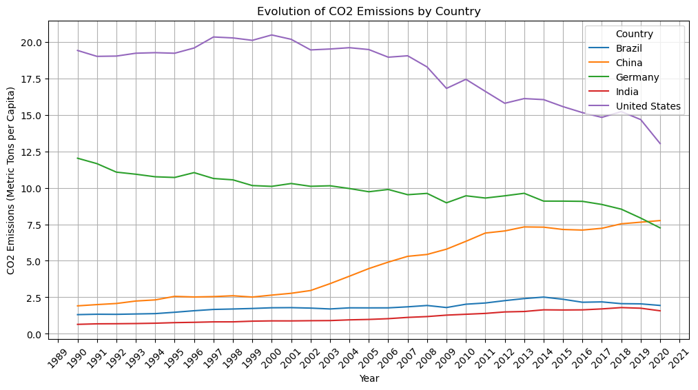

```python
# Graph 1: Evolution of CO2 emissions for each selected country
plt.figure(figsize=(12, 6))
sns.lineplot(data=filtered_df[filtered_df['Series Name'] == indicator_1],
             x='Year', y='Value', hue='Country Name')
plt.title('Evolution of CO2 Emissions by Country')
plt.ylabel('CO2 Emissions (Metric Tons per Capita)')
plt.xlabel('Year')
plt.xticks(rotation=45)
plt.legend(title='Country')
plt.grid(True)
plt.show()
```

### Second graph

In the second graph, we compare the GDP growth for selected countries, visualizing the data over the years. Seaborn is employed to create a line plot, where the x-axis represents the years, the y-axis corresponds to GDP growth values, and different lines indicate each country. The plot is presented with a title, labeled axes, legend, and grid lines, tailored for educational use in a Jupyter notebook.

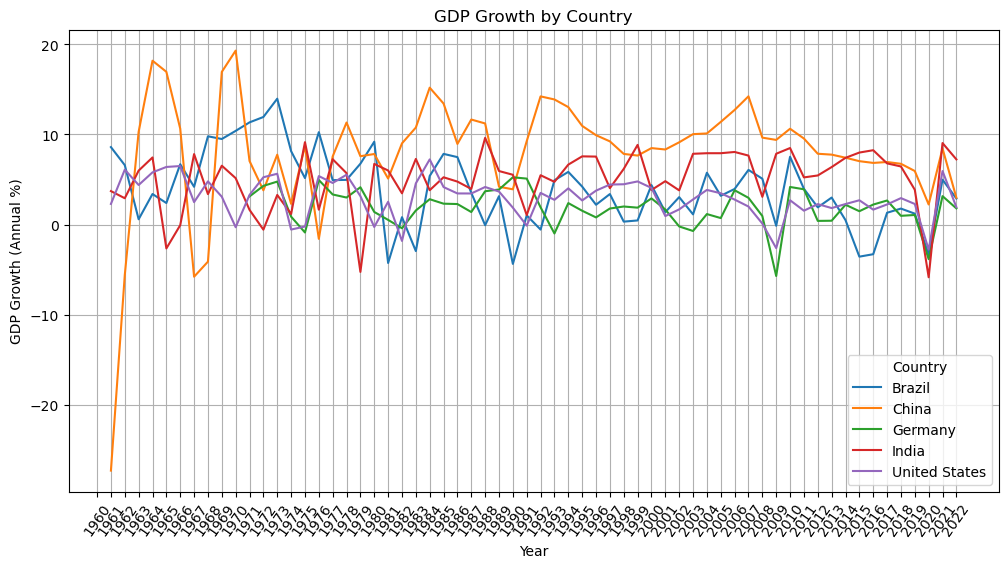

```python
# Graph 2: Comparison of GDP growth for each selected country
plt.figure(figsize=(12, 6))
sns.lineplot(data=filtered_df[filtered_df['Series Name'] == indicator_2],
             x='Year', y='Value', hue='Country Name')
plt.title('GDP Growth by Country')
plt.ylabel('GDP Growth (Annual %)')
plt.xlabel('Year')
plt.xticks(rotation=55)
plt.legend(title='Country')
plt.grid(True)
plt.show()
```

### Third graph

For this code we filter and prepare data only for China, focusing on CO2 emissions and GDP growth indicators. It extracts relevant rows from the original DataFrame (df_melted), ensures numeric formatting for the 'Year,' retains data from 1990 onwards, and removes unnecessary columns before displaying the result.

```python
indicator_1 = 'CO2 emissions (metric tons per capita)'
indicator_2 = 'GDP growth (annual %)'

df_China = df_melted[(df_melted['Series Name'].isin([indicator_1, indicator_2])) &
                      (df_melted['Country Name'].isin(['China']))]

df_China['Year'] = pd.to_numeric(df_China['Year'], errors='coerce')
df_China = df_China[df_China['Year'] >= 1990]
df_China = df_China.drop(columns =['Country Code', 'Series Code'])
df_China.head()
```

|  | Country Name | Series Name | Year | Value |
| --- | --- | --- | --- | --- |
| 48278 | China | CO2 emissions (metric tons per capita) | 1990 | 1.91454626338438 |
| 48279 | China | GDP growth (annual %) | 1990 | 3.92025136776569 |
| 49879 | China | CO2 emissions (metric tons per capita) | 1991 | 2.00054328368585 |
| 49880 | China | GDP growth (annual %) | 1991 | 9.26278608406234 |
| 51480 | China | CO2 emissions (metric tons per capita) | 1992 | 2.07574040533233 |

```python
# We filter relevant rows and select necessary columns
df_filtered = df_China[df_China['Series Name'].isin(['CO2 emissions (metric tons per capita)', 'GDP growth (annual %)'])]

# We pivot the DataFrame to obtain desired columns
df_pivoted = df_filtered.pivot(index=['Country Name', 'Year'], columns='Series Name', values='Value').reset_index()

# We rename columns if necessary
df_pivoted.columns.name = None  # To remove column names after pivoting
df_pivoted.rename(columns={
    'CO2 emissions (metric tons per capita)': 'CO2_emissions',
    'GDP growth (annual %)': 'GDP_growth'
}, inplace=True)

# We convert columns 'Year', 'CO2_emissions', and 'GDP_growth' to numeric types
df_pivoted['Year'] = pd.to_numeric(df_pivoted['Year'], errors='coerce')
df_pivoted['CO2_emissions'] = pd.to_numeric(df_pivoted['CO2_emissions'], errors='coerce')
df_pivoted['GDP_growth'] = pd.to_numeric(df_pivoted['GDP_growth'], errors='coerce')
df_pivoted.head()
```

|  | Country Name | Year | CO2_emissions | GDP_growth |
| --- | --- | --- | --- | --- |
| 0 | China | 1990 | 1.914546 | 3.920251 |
| 1 | China | 1991 | 2.000543 | 9.262786 |
| 2 | China | 1992 | 2.075740 | 14.224530 |
| 3 | China | 1993 | 2.244842 | 13.883729 |
| 4 | China | 1994 | 2.322189 | 13.036807 |

Now we define a function `plot_time_series` to create a time series plot on a given set of axes. It takes input parameters for x-axis values (`x`), y-axis values (`y`), color of the plot (`color`), and labels for the x-axis (`xlabel`) and y-axis (`ylabel`). The function uses the provided information to plot the time series, set axis labels, and adjust tick parameters on the y-axis to match the specified color. This function is designed for the final project of the QLAB Summer Python Course, as indicated in the docstring.

```python
def plot_time_series(axes, x, y, color, xlabel, ylabel):
    ''' This function plots a time series, taking the axes, x-axis values, y-axis values, color, and axis labels.
        It was designed for the final project of the QLAB Summer Python Course

        Inputs:

        axes: The axes being worked on
        x: Dates for the x-axis (usually the index)
        y: Values for the y-axis
        color: Color of the axes
        xlabel: Label for the x-axis
        ylabel: Label for the y-axis
    '''

    axes.plot(x, y, color=color)

    axes.set_xlabel(xlabel)

    axes.set_ylabel(ylabel, color=color)

    axes.tick_params(axis='y', colors=color)
```

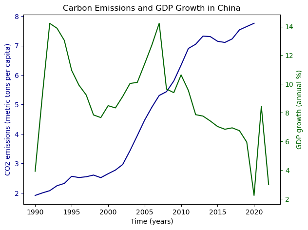

```python
plt.style.use('default')

fig, ax = plt.subplots()

plt.title('Carbon Emissions and GDP Growth in China')

plot_time_series(ax, df_pivoted.Year, df_pivoted.CO2_emissions,
                        "darkblue", 'Time (years)', 'CO2 emissions (metric tons per capita)')

ax2 = ax.twinx()

plot_time_series(ax2, df_pivoted.Year, df_pivoted.GDP_growth,
                        "darkgreen", 'Time (years)', 'GDP growth (annual %)')

fig.tight_layout(pad=1.0)

plt.show()
```

### Forth graph

We transform the dataset by consolidating scattered year columns into a unified "Year" column. Then, we select two indicators, 'Access to electricity (% of population)' and 'Hospital beds (per 1,000 people)', filter and prepare the data accordingly. The datasets for each indicator are then merged based on country and year. Subsequently, a scatter plot is generated using seaborn, depicting the relationship between access to electricity and hospital beds per country. The plot is adorned with descriptive labels and grid lines for enhanced clarity in visualizing these indicators across different countries.

```python
# We transform year columns into a single "Year" column
year_columns = [col for col in df.columns if col.startswith('19') or col.startswith('20')]
df_melted = df.melt(id_vars=['Country Name', 'Country Code', 'Series Name', 'Series Code'],
                    value_vars=year_columns,
                    var_name='Year',
                    value_name='Value')
df_melted['Year'] = df_melted['Year'].str.extract('(\d{4})')

# We select two indicators to analyze their relationship
indicator_1 = 'Access to electricity (% of population)'
indicator_2 = 'Hospital beds (per 1,000 people)'

# We filter and prepare the data
df_indicator_1 = df_melted[df_melted['Series Name'] == indicator_1]
df_indicator_2 = df_melted[df_melted['Series Name'] == indicator_2]
df_indicator_1['Value'] = pd.to_numeric(df_indicator_1['Value'], errors='coerce')
df_indicator_2['Value'] = pd.to_numeric(df_indicator_2['Value'], errors='coerce')
df_merged = pd.merge(df_indicator_1, df_indicator_2, on=['Country Name', 'Year'], suffixes=('_Electricity', '_Beds'))
```

```python
# We create a dictionary to map each country with a continent
paises_continentes = {
    'Afghanistan': 'South Asia',
    'Albania': 'Europe & Central Asia',
    'Algeria': 'Middle East & North Africa',
    'American Samoa': 'East Asia & Pacific',
    'Andorra': 'Europe & Central Asia',
    'Angola': 'Sub-Saharan Africa',
    'Antigua and Barbuda': 'Latin America & Caribbean',
    'Argentina': 'Latin America & Caribbean',
    'Armenia': 'Europe & Central Asia',
    'Aruba': 'Latin America & Caribbean',
    'Australia': 'East Asia & Pacific',
    'Austria': 'Europe & Central Asia',
    'Azerbaijan': 'Europe & Central Asia',
    'Bahamas, The': 'Latin America & Caribbean',
    'Bahrain': 'Middle East & North Africa',
    'Bangladesh': 'South Asia',
    'Barbados': 'Latin America & Caribbean',
    'Belarus': 'Europe & Central Asia',
    'Belgium': 'Europe & Central Asia',
    'Belize': 'Latin America & Caribbean',
    'Benin': 'Sub-Saharan Africa',
    'Bermuda': 'North America',
    'Bhutan': 'South Asia',
    'Bolivia': 'Latin America & Caribbean',
    'Bosnia and Herzegovina': 'Europe & Central Asia',
    'Botswana': 'Sub-Saharan Africa',
    'Brazil': 'Latin America & Caribbean',
    'British Virgin Islands': 'Latin America & Caribbean',
    'Brunei Darussalam': 'East Asia & Pacific',
    'Bulgaria': 'Europe & Central Asia',
    'Burkina Faso': 'Sub-Saharan Africa',
    'Burundi': 'Sub-Saharan Africa',
    'Cabo Verde': 'Sub-Saharan Africa',
    'Cambodia': 'East Asia & Pacific',
    'Cameroon': 'Sub-Saharan Africa',
    'Canada': 'North America',
    'Cayman Islands': 'Latin America & Caribbean',
    'Central African Republic': 'Sub-Saharan Africa',
    'Chad': 'Sub-Saharan Africa',
    'Channel Islands': 'Europe & Central Asia',
    'Chile': 'Latin America & Caribbean',
    'China': 'East Asia & Pacific',
    'Colombia': 'Latin America & Caribbean',
    'Comoros': 'Sub-Saharan Africa',
    'Congo, Dem. Rep.': 'Sub-Saharan Africa',
    'Congo, Rep.': 'Sub-Saharan Africa',
    'Costa Rica': 'Latin America & Caribbean',
    "Cote d'Ivoire": 'Sub-Saharan Africa',
    'Croatia': 'Europe & Central Asia',
    'Cuba': 'Latin America & Caribbean',
    'Curacao': 'Latin America & Caribbean',
    'Cyprus': 'Europe & Central Asia',
    'Czechia': 'Europe & Central Asia',
    'Denmark': 'Europe & Central Asia',
    'Djibouti': 'Middle East & North Africa',
    'Dominica': 'Latin America & Caribbean',
    'Dominican Republic': 'Latin America & Caribbean',
    'Ecuador': 'Latin America & Caribbean',
    'Egypt, Arab Rep.': 'Middle East & North Africa',
    'El Salvador': 'Latin America & Caribbean',
    'Equatorial Guinea': 'Sub-Saharan Africa',
    'Eritrea': 'Sub-Saharan Africa',
    'Estonia': 'Europe & Central Asia',
    'Eswatini': 'Sub-Saharan Africa',
    'Ethiopia': 'Sub-Saharan Africa',
    'Faroe Islands': 'Europe & Central Asia',
    'Fiji': 'East Asia & Pacific',
    'Finland': 'Europe & Central Asia',
    'France': 'Europe & Central Asia',
    'French Polynesia': 'East Asia & Pacific',
    'Gabon': 'Sub-Saharan Africa',
    'Gambia, The': 'Sub-Saharan Africa',
    'Georgia': 'Europe & Central Asia',
    'Germany': 'Europe & Central Asia',
    'Ghana': 'Sub-Saharan Africa',
    'Gibraltar': 'Europe & Central Asia',
    'Greece': 'Europe & Central Asia',
    'Greenland': 'North America',
    'Grenada': 'Latin America & Caribbean',
    'Guam': 'East Asia & Pacific',
    'Guatemala': 'Latin America & Caribbean',
    'Guinea': 'Sub-Saharan Africa',
    'Guinea-Bissau': 'Sub-Saharan Africa',
    'Guyana': 'Latin America & Caribbean',
    'Haiti': 'Latin America & Caribbean',
    'Honduras': 'Latin America & Caribbean',
    'Hong Kong SAR, China': 'East Asia & Pacific',
    'Hungary': 'Europe & Central Asia',
    'Iceland': 'Europe & Central Asia',
    'India': 'South Asia',
    'Iran, Islamic Rep.': 'Middle East & North Africa',
    'Iraq': 'Middle East & North Africa',
    'Ireland': 'Europe & Central Asia',
    'Isle of Man': 'Europe & Central Asia',
    'Israel': 'Middle East & North Africa',
    'Italy': 'Europe & Central Asia',
    'Jamaica': 'Latin America & Caribbean',
    'Japan': 'East Asia & Pacific',
    'Jordan': 'Middle East & North Africa',
    'Kazakhstan': 'Europe & Central Asia',
    'Kenya': 'Sub-Saharan Africa',
    'Kiribati': 'East Asia & Pacific',
    "Korea, Dem. People's Rep.": 'East Asia & Pacific',
    'Korea, Rep.': 'East Asia & Pacific',
    'Kosovo': 'Europe & Central Asia',
    'Kuwait': 'Middle East & North Africa',
    'Kyrgyz Republic': 'Europe & Central Asia',
    'Lao PDR': 'East Asia & Pacific',
    'Latvia': 'Europe & Central Asia',
    'Lebanon': 'Middle East & North Africa',
    'Lesotho': 'Sub-Saharan Africa',
    'Liberia': 'Sub-Saharan Africa',
    'Libya': 'Middle East & North Africa',
    'Liechtenstein': 'Europe & Central Asia',
    'Lithuania': 'Europe & Central Asia',
    'Luxembourg': 'Europe & Central Asia',
    'Macao SAR, China': 'East Asia & Pacific',
    'Madagascar': 'Sub-Saharan Africa',
    'Malawi': 'Sub-Saharan Africa',
    'Malaysia': 'East Asia & Pacific',
    'Maldives': 'South Asia',
    'Mali': 'Sub-Saharan Africa',
    'Malta': 'Europe & Central Asia',
    'Marshall Islands': 'East Asia & Pacific',
    'Mauritania': 'Sub-Saharan Africa',
    'Mauritius': 'Sub-Saharan Africa',
    'Mexico': 'Latin America & Caribbean',
    'Micronesia, Fed. Sts.': 'East Asia & Pacific',
    'Moldova': 'Europe & Central Asia',
    'Monaco': 'Europe & Central Asia',
    'Mongolia': 'East Asia & Pacific',
    'Montenegro': 'Europe & Central Asia',
    'Morocco': 'Middle East & North Africa',
    'Mozambique': 'Sub-Saharan Africa',
    'Myanmar': 'East Asia & Pacific',
    'Namibia': 'Sub-Saharan Africa',
    'Nauru': 'East Asia & Pacific',
    'Nepal': 'South Asia',
    'Netherlands': 'Europe & Central Asia',
    'New Caledonia': 'East Asia & Pacific',
    'New Zealand': 'East Asia & Pacific',
    'Nicaragua': 'Latin America & Caribbean',
    'Niger': 'Sub-Saharan Africa',
    'Nigeria': 'Sub-Saharan Africa',
    'North Macedonia': 'Europe & Central Asia',
    'Northern Mariana Islands': 'East Asia & Pacific',
    'Norway': 'Europe & Central Asia',
    'Oman': 'Middle East & North Africa',
    'Pakistan': 'South Asia',
    'Palau': 'East Asia & Pacific',
    'Panama': 'Latin America & Caribbean',
    'Papua New Guinea': 'East Asia & Pacific',
    'Paraguay': 'Latin America & Caribbean',
    'Peru': 'Latin America & Caribbean',
    'Philippines': 'East Asia & Pacific',
    'Poland': 'Europe & Central Asia',
    'Portugal': 'Europe & Central Asia',
    'Puerto Rico': 'Latin America & Caribbean',
    'Qatar': 'Middle East & North Africa',
    'Romania': 'Europe & Central Asia',
    'Russian Federation': 'Europe & Central Asia',
    'Rwanda': 'Sub-Saharan Africa',
    'Samoa': 'East Asia & Pacific',
    'San Marino': 'Europe & Central Asia',
    'Sao Tome and Principe': 'Sub-Saharan Africa',
    'Saudi Arabia': 'Middle East & North Africa',
    'Senegal': 'Sub-Saharan Africa',
    'Serbia': 'Europe & Central Asia',
    'Seychelles': 'Sub-Saharan Africa',
    'Sierra Leone': 'Sub-Saharan Africa',
    'Singapore': 'East Asia & Pacific',
    'Sint Maarten (Dutch part)': 'Latin America & Caribbean',
    'Slovak Republic': 'Europe & Central Asia',
    'Slovenia': 'Europe & Central Asia',
    'Solomon Islands': 'East Asia & Pacific',
    'Somalia': 'Sub-Saharan Africa',
    'South Africa': 'Sub-Saharan Africa',
    'South Sudan': 'Sub-Saharan Africa',
    'Spain': 'Europe & Central Asia',
    'Sri Lanka': 'South Asia',
    'St. Kitts and Nevis': 'Latin America & Caribbean',
    'St. Lucia': 'Latin America & Caribbean',
    'St. Martin (French part)': 'Latin America & Caribbean',
    'St. Vincent and the Grenadines': 'Latin America & Caribbean',
    'Sudan': 'Sub-Saharan Africa',
    'Suriname': 'Latin America & Caribbean',
    'Sweden': 'Europe & Central Asia',
    'Switzerland': 'Europe & Central Asia',
    'Syrian Arab Republic': 'Middle East & North Africa',
    'Tajikistan': 'Europe & Central Asia',
    'Tanzania': 'Sub-Saharan Africa',
    'Thailand': 'East Asia & Pacific',
    'Timor-Leste': 'East Asia & Pacific',
    'Togo': 'Sub-Saharan Africa',
    'Tonga': 'East Asia & Pacific',
    'Trinidad and Tobago': 'Latin America & Caribbean',
    'Tunisia': 'Middle East & North Africa',
    'Turkiye': 'Europe & Central Asia',
    'Turkmenistan': 'Europe & Central Asia',
    'Turks and Caicos Islands': 'Latin America & Caribbean',
    'Tuvalu': 'East Asia & Pacific',
    'Uganda': 'Sub-Saharan Africa',
    'Ukraine': 'Europe & Central Asia',
    'United Arab Emirates': 'Middle East & North Africa',
    'United Kingdom': 'Europe & Central Asia',
    'United States': 'North America',
    'Uruguay': 'Latin America & Caribbean',
    'Uzbekistan': 'Europe & Central Asia',
    'Vanuatu': 'East Asia & Pacific',
    'Venezuela, RB': 'Latin America & Caribbean',
    'Viet Nam': 'East Asia & Pacific',
    'Virgin Islands (U.S.)': 'Latin America & Caribbean',
    'West Bank and Gaza': 'Middle East & North Africa',
    'Yemen, Rep.': 'Middle East & North Africa',
    'Zambia': 'Sub-Saharan Africa',
    'Zimbabwe': 'Sub-Saharan Africa',
    'Africa Eastern and Southern': 'Others',
    'Africa Western and Central': 'Others',
    'Arab World': 'Others',
    'Caribbean small states': 'Others',
    'Central Europe and the Baltics': 'Others',
    'Early-demographic dividend': 'Others',
    'East Asia & Pacific': 'Others',
    'East Asia & Pacific (excluding high income)': 'Others',
    'East Asia & Pacific (IDA & IBRD countries)': 'Others',
    'Euro area': 'Others',
    'Europe & Central Asia': 'Others',
    'Europe & Central Asia (excluding high income)': 'Others',
    'Europe & Central Asia (IDA & IBRD countries)': 'Others',
    'European Union': 'Others',
    'Fragile and conflict affected situations': 'Others',
    'Heavily indebted poor countries (HIPC)': 'Others',
    'High income': 'Others',
    'IBRD only': 'Others',
    'IDA & IBRD total': 'Others',
    'IDA blend': 'Others',
    'IDA only': 'Others',
    'IDA total': 'Others',
    'Late-demographic dividend': 'Others',
    'Latin America & Caribbean': 'Others',
    'Latin America & Caribbean (excluding high income)': 'Others',
    'Latin America & the Caribbean (IDA & IBRD countries)': 'Others',
    'Least developed countries: UN classification': 'Others',
    'Low & middle income': 'Others',
    'Low income': 'Others',
    'Lower middle income': 'Others',
    'Middle East & North Africa': 'Others',
    'Middle East & North Africa (excluding high income)': 'Others',
    'Middle East & North Africa (IDA & IBRD countries)': 'Others',
    'Middle income': 'Others',
    'North America': 'Others',
    'Not classified': 'Others',
    'OECD members': 'Others',
    'Other small states': 'Others',
    'Pacific island small states': 'Others',
    'Post-demographic dividend': 'Others',
    'Pre-demographic dividend': 'Others',
    'Small states': 'Others',
    'South Asia': 'Others',
    'South Asia (IDA & IBRD)': 'Others',
    'Sub-Saharan Africa': 'Others',
    'Sub-Saharan Africa (excluding high income)': 'Others',
    'Sub-Saharan Africa (IDA & IBRD countries)': 'Others',
    'Upper middle income': 'Others',
    'World': 'Others'
}
```

```python
# We add the continent columns
df_merged['Continent'] = df_merged['Country Name'].map(paises_continentes)
```

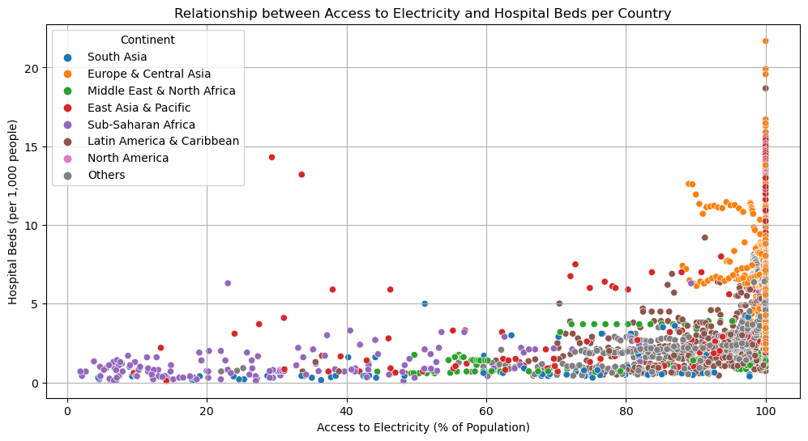

```python
# We create the scatter plot
plt.figure(figsize=(12, 6))
sns.scatterplot(data=df_merged, x='Value_Electricity', y='Value_Beds', hue='Continent')
plt.title('Relationship between Access to Electricity and Hospital Beds per Country')
plt.xlabel('Access to Electricity (% of Population)')
plt.ylabel('Hospital Beds (per 1,000 people)')
plt.grid(True)
plt.show()
```